# Residuals

## Residuals

**Residuals** are the difference between the observed value of $Y_i$ (data point) and the predicted (or estimated) value for that point $\hat{Y}_i$ (point on regression line)  
Residual is denoted by $r_i$ as follows:

$$r_i = \underbrace{Y_i}_\text{observed Y-value} - \underbrace{\hat{Y}_i}_\text{predicted Y-value}$$

### Residuals

How the mileage in Civics and Corollas affect their prices?

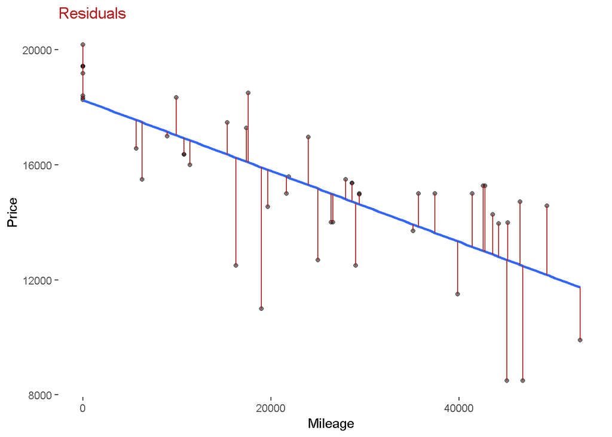

```r
lm1 <- lm(Price ~ Mileage, data = cc)

lm1 %>%
  ggplot(aes(Mileage, Price)) +
  geom_point(aes(), alpha = .5) +
  geom_smooth(method = "lm", se = F, alpha = ".5") +
  geom_segment(aes(xend = Mileage, yend = predict(lm1)), color = "firebrick") +
  labs(title = "Residuals",
       x = "Mileage",
       y = "Price") +
  myTheme +
  theme(plot.title = element_text(color = "firebrick"))
```

Knowing a single residual is useful, for example, to learn if a car is sold above or bellow average according to its mileage  
How would it apply for your car?

- `Mileage`: 16296
- `Price`: $12499

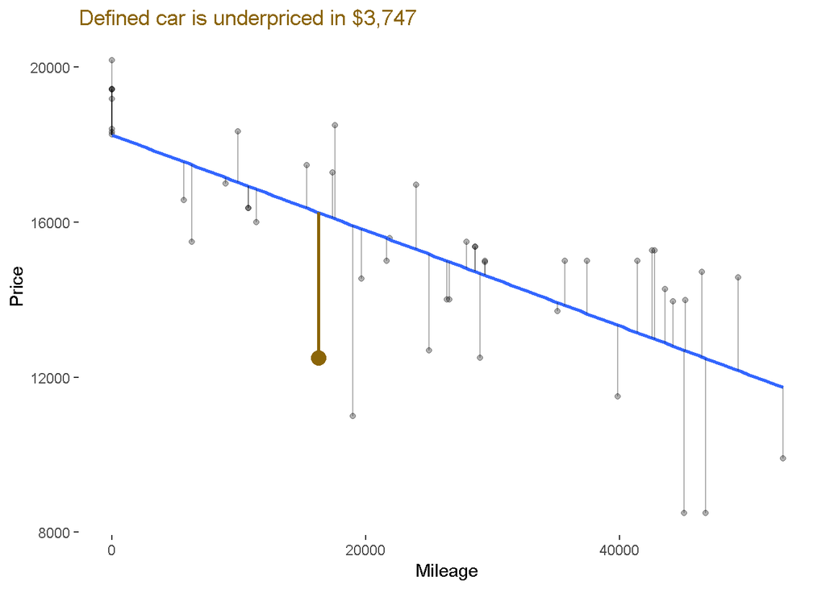

```r
x <- cc %>% filter(Mileage == 16296, Price == 12499)

lm1 %>%
  ggplot(aes(Mileage, Price)) +
  geom_point(aes(), alpha = .3) +
  geom_point(x = 16296, y = 12499, color = "darkgoldenrod4", size = 4) +
  geom_smooth(method = "lm", se = F, alpha = ".5") +
  geom_segment(aes(xend = Mileage, yend = predict(lm1)), alpha = .3) +
  geom_segment(aes(), data = x, xend = 16296, yend = predict(lm1, data.frame(Mileage = 16296)), color = "darkgoldenrod4", size = 1) +
  labs(title = "Defined car is underpriced in $3,747",
       x = "Mileage",
       y = "Price") +
  myTheme +
  theme(plot.title = element_text(color = "darkgoldenrod4"))
```

Model of the calculation above:

$$\underbrace{-3,747}_\text{residual} = \underbrace{12,499}_\text{observed price} - \underbrace{16,246}_\text{predicted price}$$

### Sum of Squares

There are 3 important ways we can measure the fit of a line:

- `SSE`
- `SSR`
- `SSTO`

The concept for each sum of squares are found in the next tabs.

#### Sum of Squared Errors | `SSE`

`SSE` measures how much the **residuals** (or y-values) deviate form the **line** (regression line)

How to calculate `SSE`:

$SSTO - SSR$, or:

```r
sum((Y - mylm$fit)^2)
```

The lowest the `SSE` is, the better. Meaning that the residuals are low and the observed values are not very far from the regression line.

#### Sum of Squares Regression | `SSR`

`SSR` measures how much the **regression line** deviates from the **average Y-value**

How to calculate `SSR`:

$SSTO - SSE$, or:

```r
sum((mylm$fit - mean(Y))^2)
```

The largest the `SSR` is, the better, because means that `SSE` is small.

#### Total Sum of Squares | `SSTO`

`SSTO` measures how much the **y-values** (or residuals) deviate from the **average Y-value**

How to calculate `SSTO`:

$SSE + SSR$, or:

```r
sum((Y - mean(Y))^2)
```

The concepts of the **sum of squares** are important because lead us to **R-squared ($R^2$)** in the next tab.

### R-squared

$R^2$ is the proportion of variance in $Y$, telling how well the data fit the regression model. R-squared can vary from 0 to 1. The highest the value, the better is the fit.

$R^2$ represents the percent of the data that fits the regression model.

The $R^2$ can be found on the following ways:

$SSR \over{SSTO}$  
$1 - {SSE \over{SSTO}}$  
${\underbrace{r}_\text{correlation}} ^2$